# NZ SRW Calving interval report

Anthony Davidson

14 September, 2017

# Raw data

The data is then converted into intervals for each of the years 2010, 2011, 2012 and 2013.

A table of the raw results as the year increase

| year | n | mY | low.qt | high.qt | sd |
| --- | --- | --- | --- | --- | --- |
| 2010 | 3 | 2.666667 | 1.605851 | 3.727482 | 0.5773503 |
| 2011 | 15 | 2.866667 | 2.673022 | 3.060312 | 0.3518658 |
| 2012 | 25 | 3.240000 | 2.919170 | 3.560830 | 0.7788881 |
| 2013 | 45 | 3.311111 | 3.056488 | 3.565734 | 0.8480518 |

The raw intervals can be presented as different means and confidence intervals as the length of the study increases:

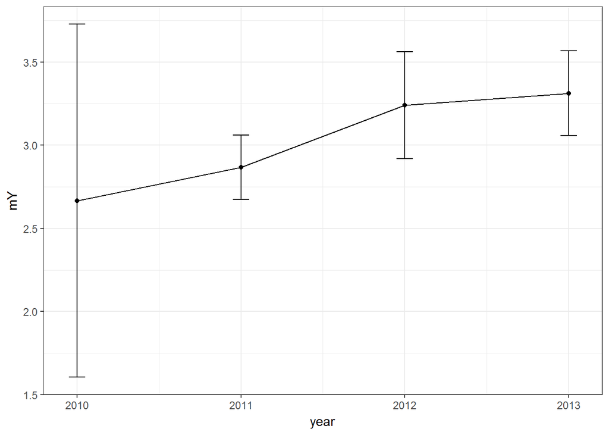

We can also plot these as bar charts that show this more obviously:

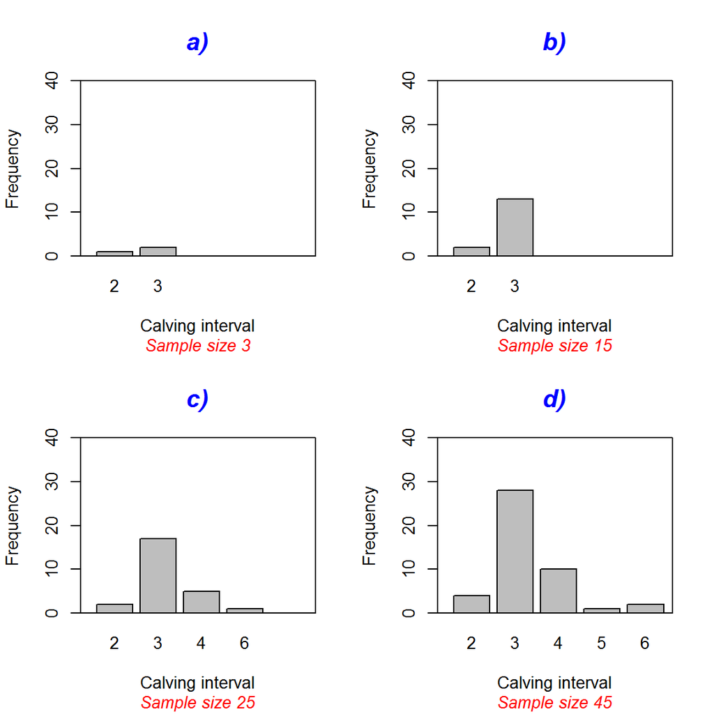

What is interesting is that in 2011 there were more intervals that subsequently reduced the standard error of the estimate and the precision increased.

**My idea of why this has happened is as follows:**

At the time of collection in 2011 the number of possible intervals greater than 5 was very unlikely (as there where only 5 years of research). This meant that the overall error of the estimate was reduced as there was very few “chances” of obtaining a calving interval of 5 or 6 even though there may have been quite a few. The following estimates then picked these up and the error in the estimate increased again.

### Publication plot (Figure 2)

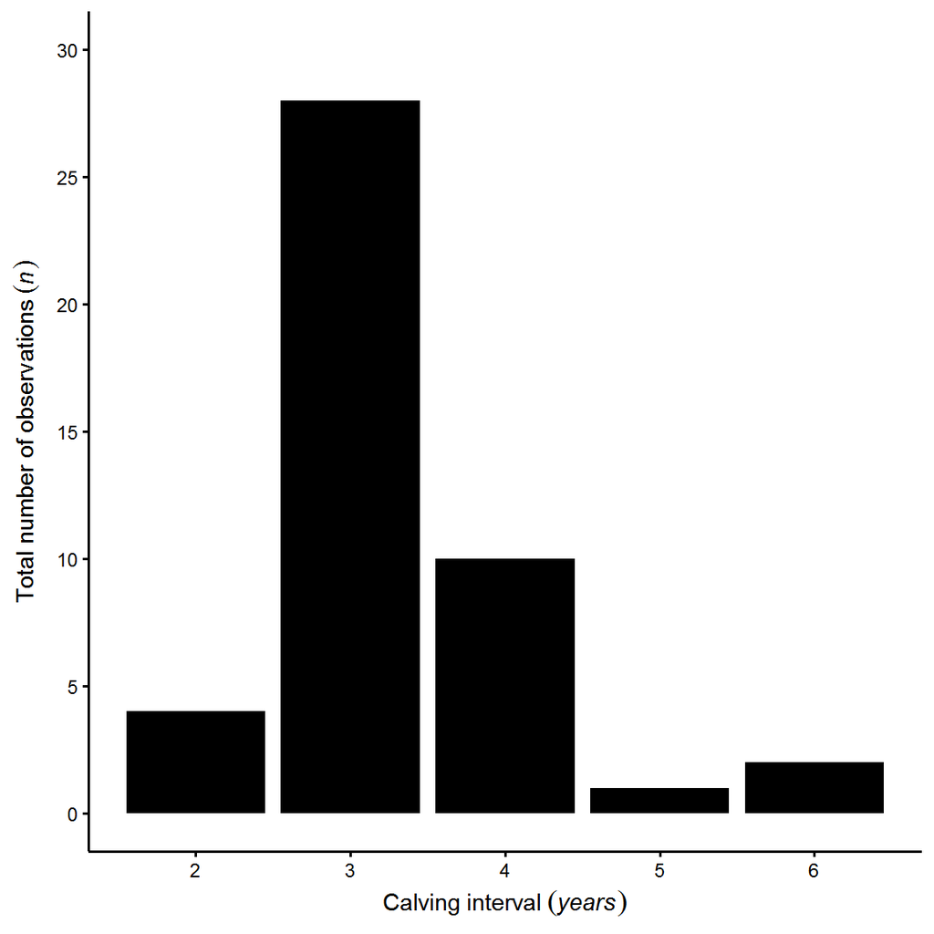

# Missing intervals (Bradford et al. 2008)

This is a way to see what the calving interval might be if we had in fact missed calving events that happened before or after the study period.

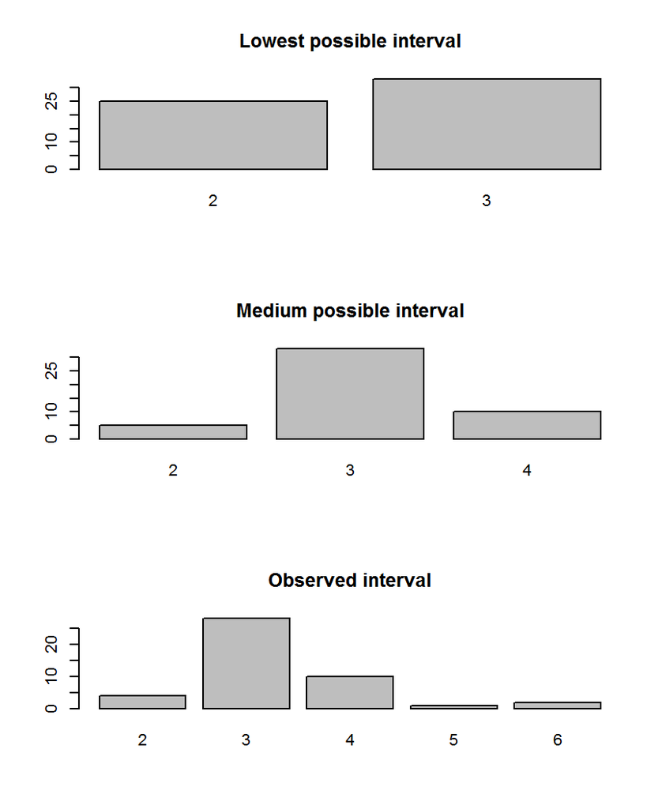

### Publication plot (Not included in final publication)

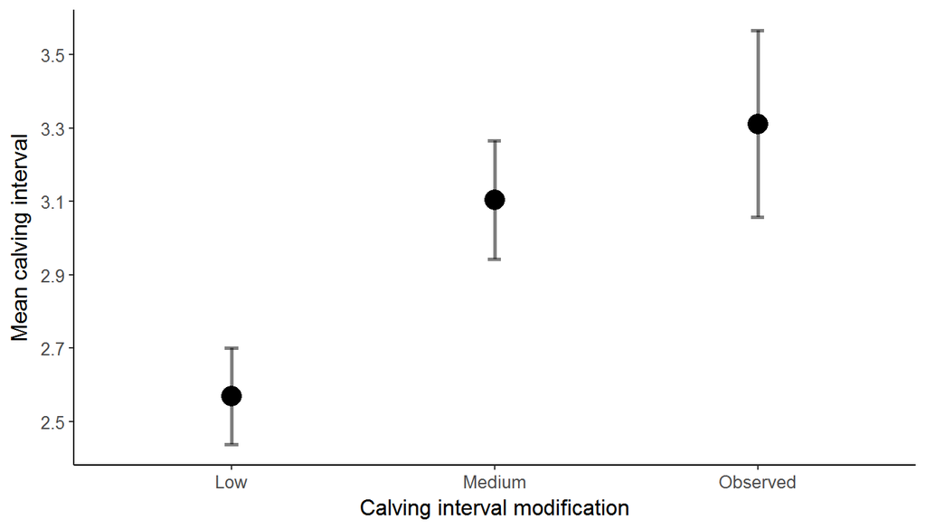

The error gets smaller as the variance in the estimate decreases. We are artificially doing this here by modifying data to match what maybe more biologically possible.

| Interval | Sample size | Mean | Lower limit | Higher limit | SD |
| --- | --- | --- | --- | --- | --- |
| Low | 58 | 2.568966 | 2.437666 | 2.700265 | 0.4995461 |
| Medium | 48 | 3.104167 | 2.943089 | 3.265244 | 0.5550382 |
| Observed | 45 | 3.311111 | 3.056488 | 3.565734 | 0.8480518 |

# Bootstrapping

Below is the estimates from other populations of SRWs around the world.

| Sample size | Mean | Lower limit | Higher limit | SE | Author | Location |
| --- | --- | --- | --- | --- | --- | --- |
| NA | 3.12 | 3.07 | 3.17 | NA | Best et al. 2001 | South Africa |
| 1504 | 3.15 | 3.11 | 3.18 | NA | Best et al. 2005 | South Africa (1971-2003 Updated) |
| NA | 3.16 | 3.13 | 3.19 | NA | Brandao et al 2010 | South Africa ( 1971-2006 Updated) |
| NA | 3.35 | NA | NA | 0.05 | Cooke et al. 2001 | Argentina |
| 749 | 3.42 | NA | NA | 0.11 | Cooke et al. 2003 | Argentina |
| NA | 3.63 | NA | NA | 0.13 | Burnell 2001 | Australia |

**Table of parameters:** This is taken directly from my Master’s thesis. There may be updated estimates that need to be checked here.

## Single bootstrap with increased sample size

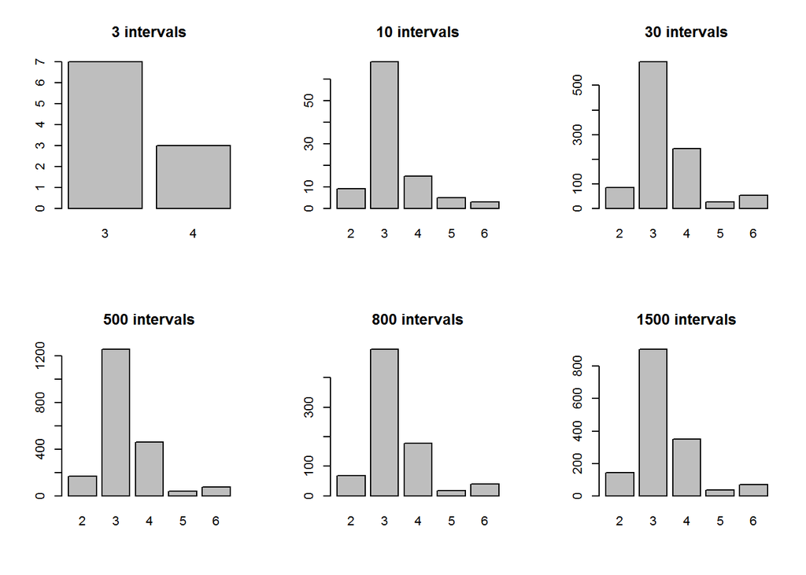

### Publication plot (Figure 3)

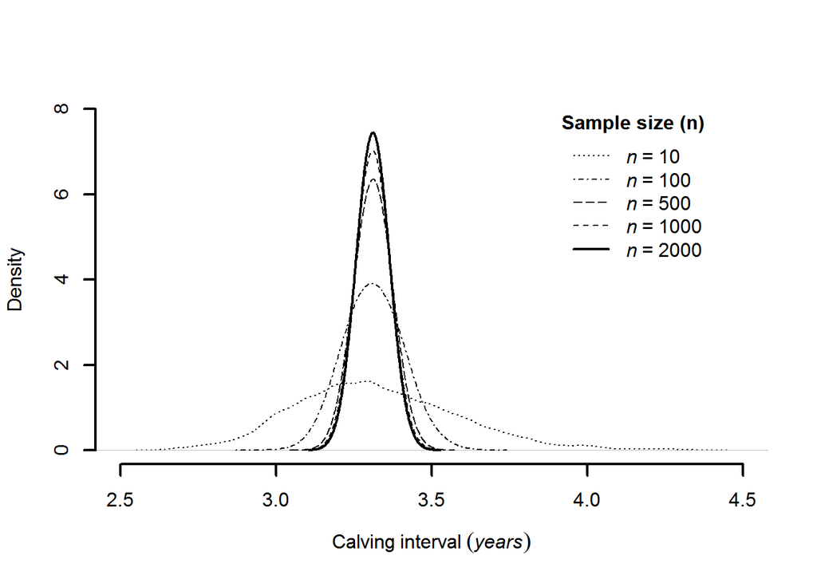

# Referees additional analysis

## Suggestion one

**“If another 45 samples were collected over the next 8 years, but the mean moved from 3.31 to e.g., 3.7 years, would it be detectable with alpha = 0.05, 0.10 … ? Given that other authors have hypothesised that poor food availability would translate to increased calving intervals/calf mortalities (e.g., Cooke et al 2003, Rowntree et al 2013), being able to detect such a change would be important.”**

To do this it is simply a old school power analysis with the focus on the type one error (alpha) as below:

```r
#observed sample
rev.one <- bdata$RealCI[1:45]

#sample 45 times
sample.true <- sample(rev.one,45,replace=T)

#power analysis
pwr.test.results <- power.t.test(n = 45,# sample size
             delta = seq(0,0.99,0.001),  #difference between means
             sd = sd(sample.true),      #observed variation
             alternative = "one.sided", #observed test type
             sig.level = 0.001)          #significance level

#additional packages are avaliable for more complex analysis
#but have not done this as don't think it is needed
```

Here I have looked at the effect of the difference in the mean to range from the same 3.31 (delta = 0) to 4.31 (delta = 1) with the same variation as observed in the observed data.

```r
#sort data into ggplot format
pwr.analysis <- as.data.frame(cbind(
                              pwr.test.results$power,
                              pwr.test.results$delta))

colnames(pwr.analysis) <- c("power","mean.diff")
glimpse(pwr.analysis)
```

```
## Observations: 991
## Variables: 2
## $ power     <dbl> 0.001000000, 0.001017324, 0.001034922, 0.001052800, ...
## $ mean.diff <dbl> 0.000, 0.001, 0.002, 0.003, 0.004, 0.005, 0.006, 0.0...
```

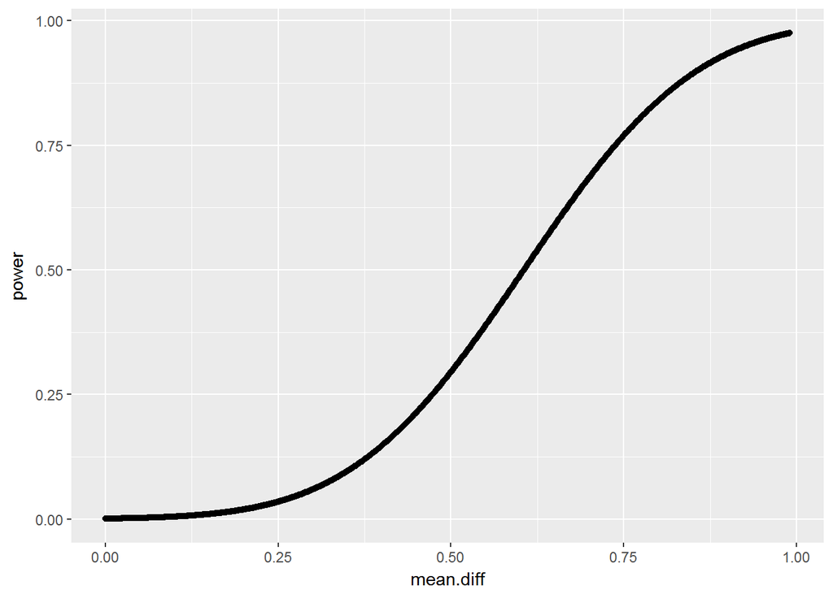

```r
#plot data
ggplot(data = pwr.analysis, aes(y = power, x = mean.diff)) +
  geom_point()
```

**Important note**

I do not this is the best approach because…

if the sampling continues over the next 8 years, the number of observations will not increase in a linear function as the number of individuals avaliable for recapture is growing (more individuals in database) at a different rate to the captue probability (that is hopefully constant). I will do the simulation recommmended because both the editor and reviewer wanted it.

I previously approached this problem by using bootstrapping and looking at the effect of the sampling size (n) increasing.

## Suggestion two

**“The existing simulation could be improved by assuming imperfect detection of calving events. For example, how does the variance around the estimate of mean calving interval change when 5% of calving events are not detected, increasing the number of 5 or 6 year observed calving intervals?”**

## Suggestion three

**“Is there any information for the females with the potentially missed calving events in the intervening years; e.g., were they seen without calves?”**

To do this the following steps are taken:

1. Raw data looks like so

```r
dat <- read.csv("C:/Users/s435389/R_packages/Davidson_2017_SRWrepro/Data/raw_observations_2012.csv")
head(dat)
```

```
##        ID X2006 X2007 X2008 X2009 X2010 X2011 X2012 total X..yrs.seen
## 1 AI06006     1     0     1     0     0     0     0     2           2
## 2 AI06007     2     1     0     0     0     0     1     4           3
## 3 AI06015     2     1     1     0     2     0     2     8           5
## 4 AI06022     1     0     0     0     0     0     4     5           2
## 5 AI06038     1     0     2     0     0     0     0     3           2
## 6 AI10040     0     0     0     0     6     0     0     6           1
```

```r
glimpse(dat)
```

```
## Observations: 180
## Variables: 10
## $ ID          <fctr> AI06006, AI06007, AI06015, AI06022, AI06038, AI10...
## $ X2006       <int> 1, 2, 2, 1, 1, 0, 0, 0, 0, 0, 0, 0, 0, 0, 0, 0, 0,...
## $ X2007       <int> 0, 1, 1, 0, 0, 0, 0, 0, 0, 0, 0, 0, 0, 0, 0, 0, 0,...
## $ X2008       <int> 1, 0, 1, 0, 2, 0, 1, 0, 0, 0, 0, 0, 0, 0, 1, 0, 0,...
## $ X2009       <int> 0, 0, 0, 0, 0, 0, 0, 0, 0, 0, 0, 0, 0, 0, 0, 0, 0,...
## $ X2010       <int> 0, 0, 2, 0, 0, 6, 6, 5, 5, 3, 4, 2, 5, 4, 5, 3, 2,...
## $ X2011       <int> 0, 0, 0, 0, 0, 0, 0, 0, 0, 0, 0, 0, 0, 0, 0, 0, 0,...
## $ X2012       <int> 0, 1, 2, 4, 0, 0, 0, 0, 0, 0, 5, 0, 0, 12, 0, 0, 0...
## $ total       <int> 2, 4, 8, 5, 3, 6, 7, 5, 5, 3, 9, 2, 5, 16, 6, 3, 2...
## $ X..yrs.seen <int> 2, 3, 5, 2, 2, 1, 2, 1, 1, 1, 2, 1, 1, 2, 2, 1, 1,...
```

```r
#change everything that is above 1 to 1
```

## Suggestion four

**“Another possibility not explored is that the reported two year calving intervals could have been an error; what would the mean calving interval be in this case?”**

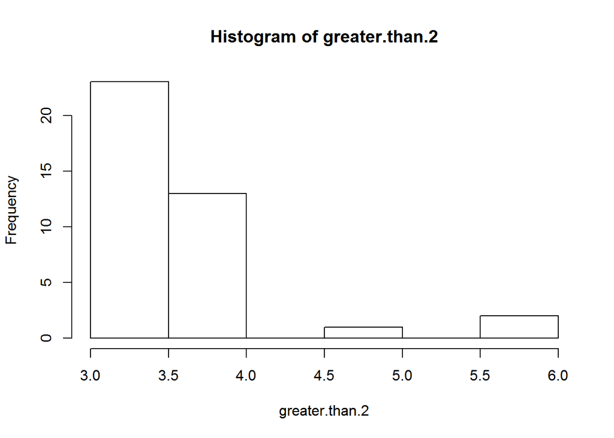

```r
greater.than.2 <- sample.true[sample.true>2]
hist(greater.than.2)
```

```r
#greater.than.2
mean.2<-sum(greater.than.2)/length(greater.than.2)
s.2<-sd(greater.than.2)
SE.2<-s2013/(sqrt(length(greater.than.2)))
n.2<-(length(greater.than.2))
low.qt.2<- mean.2-(qt(0.975,length(greater.than.2))*SE.2)
high.qt.2 <- mean.2+(qt(0.975,length(greater.than.2))*SE.2)

#mean
mean.2
```

```
## [1] 3.538462
```

```r
#95% CI
low.qt.2
```

```
## [1] 3.263786
```

```r
high.qt.2
```

```
## [1] 3.813137
```

```r
#add it to the table from bradford data
Sumtable
```

```
##   variable      short     medium      real
## 1   low.qt 2.43766564 2.94308897 3.0564880
## 2     mean 2.56896552 3.10416667 3.3111111
## 3  high.qt 2.70026540 3.26524437 3.5657343
## 4       sd 0.49954607 0.55503818 0.8480518
## 5       SE 0.06559361 0.08011286 0.1264201
```